# Day Two

Jody Holland

2023-03-21

# R and Statistics Crash Course

*Day Two*

# In detail about OLS Linear Model

OLS Linear Models denote models based on finding straight line relationships between a set of predictor variables and a response variable. This model is simply expressed as:

$$y_i= a + \beta x_i + \epsilon_i$$

In this simple two dimensional bivariate model $i$ denotes each individual replicate/data point/row in your data frame, $y$ denotes the dependent variable, $a$ denotes the intercept $\beta$ denotes the coefficient on the predictor/independent variable $x$, and $\epsilon$ denotes the case specific residual error. It is also possible to add more independent variables, transforming the model into a multidimensional regression model. This looks as follows and determines multiple coefficients for each variable:

$$y_i= a + \beta_1 x_i + \beta_2 x_i + \beta_3 x_i + \beta_ .... x_i +
\epsilon_i$$

OLS stands for Ordinary Least Squared Model, which explains a method of determining what should be the intercept and the coefficients to minimise the distance between the line and the actual values (minimising the residuals)

To evaluate an OLS Linear Model, there are several metrics/statistical tools and concepts:

## R-Squared

R<sup>2</sup> is a concept that explains the % of the variance in Y that is explained by the model. It is calculated as one minus the sum of the residuals in the model divided by the sum of the residuals explained by mean

## Distribution of Residuals

The residuals should fit a Gaussian distribution, with a clear central mean and symmetrical tails. This can be visualised by plotting the residuals as a histogram or using a Shapiro Wilk test on the residuals.

## Scedasticity

This means the manner in which the residuals change as values of $x$ increases. In theory the variance should not change throughout the model. If they do, then the model may be biased (the variance is noticable lower at certain values of $x$) or heteroscedastic (the variance shifts in both directions over the course of changes in the value of $x$).

## Multicolinearity

When using multiple independent/predictor variables, there is a change that they themselves may be correlated. This is troublesome as it waters down the value of the resulting inferences. An example of a potential case of multicolinearity is if you were working with country-level data and was using both life expectancy and GDP per capita as independent variables. The problem with this is that these two variables are highly correlated with one another. There are several ways to test for multicolinearity, such as making a bivariate Pearson’s Correlation Matrix for the independent variables in your model.

# Applying the Simple Straight Line Linear Model

The simple straight line model can be applied to many cases beyond just using different configurations of continuous (numeric) variables. Specifically, this means that the model can be used in several use cases in place of ANOVAs and T-Tests. This is through transforming a categorical variable in your data into dummy variables (using a binary operator 0 or 1 to denote if each case point is a member of that given category).

A detailed example of this process in R in shown below:

## Linear Models, 1-Factor ANOVA, and Life Expectancy

Traditionally, there is clear differences between ANOVA and OLS. In OLS both X and Y are continuous, but in ANOVA X is categorical. However if you code the categories in ANOVA as dummy variables then do an OLS. This produces results very similar to OLS

Before transformation into dummy variables

| ID | Category | Height |
| --- | --- | --- |
| 1 | Tree | 10 |
| 2 | Tree | 6 |
| 3 | Lamp | 8 |

After transformation into dummy variables

| ID | Tree | Lamp | Height |
| --- | --- | --- | --- |
| 1 | 1 | 0 | 10 |
| 2 | 1 | 0 | 6 |
| 3 | 0 | 1 | 8 |

Then you can smash this into a standard multivariate regression like so:

$$height = c + tree + lamp + e$$

Here’s an example using the continent categorical variable in gapminder data and it’s effect on life expectancy using the lm() function

```r
# load tidyverse
library(tidyverse)
# load gapminder for 2007
data_gm = gapminder::gapminder %>%
  filter(year == 2007)
# lets have a look at the data
data_gm
```

```
## # A tibble: 142 × 6
##    country     continent  year lifeExp       pop gdpPercap
##    <fct>       <fct>     <int>   <dbl>     <int>     <dbl>
##  1 Afghanistan Asia       2007    43.8  31889923      975.
##  2 Albania     Europe     2007    76.4   3600523     5937.
##  3 Algeria     Africa     2007    72.3  33333216     6223.
##  4 Angola      Africa     2007    42.7  12420476     4797.
##  5 Argentina   Americas   2007    75.3  40301927    12779.
##  6 Australia   Oceania    2007    81.2  20434176    34435.
##  7 Austria     Europe     2007    79.8   8199783    36126.
##  8 Bahrain     Asia       2007    75.6    708573    29796.
##  9 Bangladesh  Asia       2007    64.1 150448339     1391.
## 10 Belgium     Europe     2007    79.4  10392226    33693.
## # … with 132 more rows
```

Plotting this data looks as follows

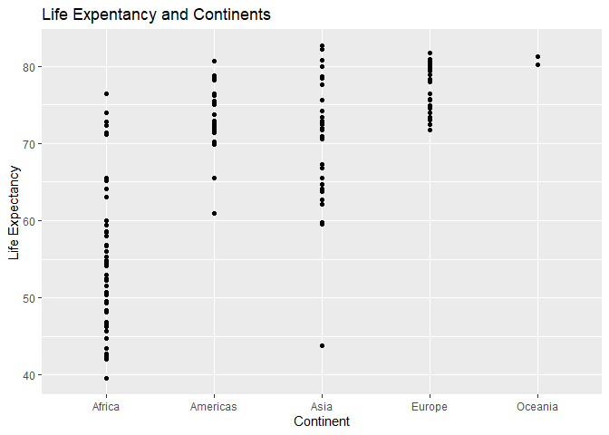

```r
# assign data and variable
ggplot(data = data_gm,
       aes(y = lifeExp, x = continent)) +
  geom_point() +
  labs(title = "Life Expentancy and Continents",
       x = "Continent",
       y = "Life Expectancy")
```

It looks like there is quite a bit of variation in the Africa group and a noticeable outlier in Asia (this is Afghanistan). Nonetheless, lets press on and accept this example will be weakened. In theory we now need to break down the continent category into columns of dummy variables, however the lm() function in R does this for us

```r
# use the lm() function
model = lm(data = data_gm,
           formula = lifeExp ~ continent)
# export summary of regression
summary(model)
```

```
##
## Call:
## lm(formula = lifeExp ~ continent, data = data_gm)
##
## Residuals:
##      Min       1Q   Median       3Q      Max
## -26.9005  -4.0399   0.2565   3.3840  21.6360
##
## Coefficients:
##                   Estimate Std. Error t value Pr(>|t|)
## (Intercept)         54.806      1.025  53.446  < 2e-16 ***
## continentAmericas   18.802      1.800  10.448  < 2e-16 ***
## continentAsia       15.922      1.646   9.675  < 2e-16 ***
## continentEurope     22.843      1.695  13.474  < 2e-16 ***
## continentOceania    25.913      5.328   4.863 3.12e-06 ***
## ---
## Signif. codes:  0 '***' 0.001 '**' 0.01 '*' 0.05 '.' 0.1 ' ' 1
##
## Residual standard error: 7.395 on 137 degrees of freedom
## Multiple R-squared:  0.6355, Adjusted R-squared:  0.6249
## F-statistic: 59.71 on 4 and 137 DF,  p-value: < 2.2e-16
```

Looking at these results, what is interesting is the intercept represents Africa, and each continent coefficient below represents the effect on life expectancy each being in each continent has relative to Africa.

We can also plot the model to see information about the model

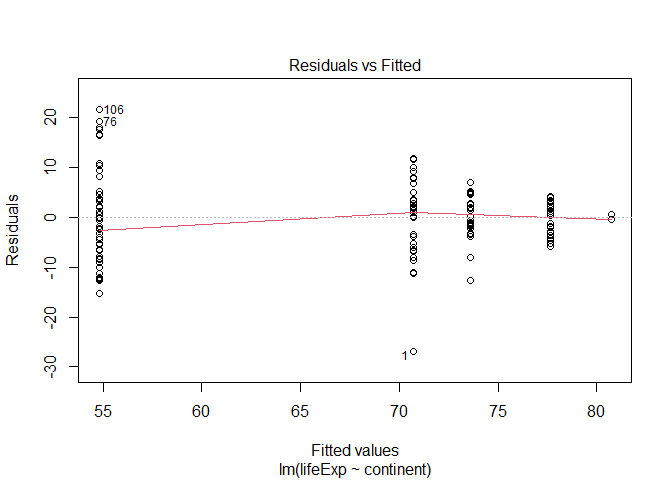

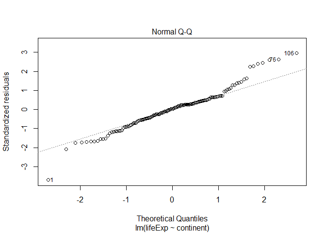

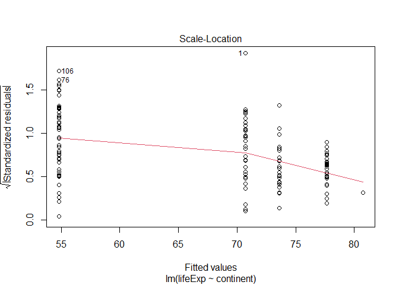

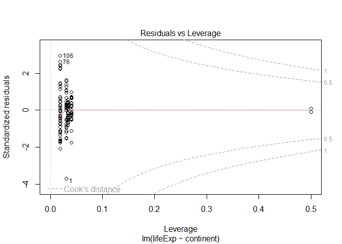

```r
plot(model)
```

We can also build a standard ANOVA output from the model. However if you look at the bottom of the summary output, you see that the F-statistic and the overall model p-value are already shown.

```r
# generate anova table
anova(model)
```

```
## Analysis of Variance Table
##
## Response: lifeExp
##            Df  Sum Sq Mean Sq F value    Pr(>F)
## continent   4 13060.7  3265.2  59.714 < 2.2e-16 ***
## Residuals 137  7491.2    54.7
## ---
## Signif. codes:  0 '***' 0.001 '**' 0.01 '*' 0.05 '.' 0.1 ' ' 1
```

It appears that maybe continental effects on life expectancy are manifest, with a significant F-statistic of 59.714 (p < 0.01) however as mentioned there are problems with this data.

# In detail about ANOVA

ANOVA stands for “Analysis of Variance”. In its simplest form, it takes one categorical variable such as location, and tests to see if there are significant differences between the groupings of this variable with regards to a given dependent variable. For instance you may want to test if a given population of fish are larger or smaller within the waters of a set of islands. In this case, which island the fish are sampled from would be your predictor variable, and the size of the fish your dependent continuous variable.

## The F-Statistic in ANOVA

ANOVA works through determining what is known as the F-statistic. This relates to the level of variance (mean distance squared between data points) between groups $MS_b$ as a ratio of the level of variance within groups $MSw$. If the level of variance between groups is larger than the level of variance between groups, then the F-statistic will be high, indicating that there is difference between the groupings. This ratio is expressed as such:

$$F=\frac{MS_b}{MS_w}$$

It is likely that a high F-Statistic will lead to a small and significant P-Value

## More Complex ANOVA

More complex models of ANOVA include more factors/independent variables (still categorical however). Going back to our island example, we could also test the temperature of sea, classifying it into different categorical groupings such as warm, lukewarm etc. To include this data, we would add the value as an interaction effect. This is where it is easier to adapt ANOVA to an OLS straight line regression model. This would look as follows:

$$Size_i=a+\beta_1Island_i+\beta_2Temperature_i + \beta_3Island_i *
Temperature_i + \epsilon_i$$

Remember that we transform the categorical into dummy variables. Thus, the pairings would self sort, as multiplying by zero equals zero.

## Assumptions of ANOVA

- The groups are normally distributed
  - This means that the values of $y$ within groupings are generally normally distributed
- The distributions are equal in
  - This means that the spread of the values of $y$ within groupings are generally pretty consistent
- Outliers are identified
  - There are many reasons for outliers, and many ways to deal with them. Important however to check how the data was gathered in case there has been an error

## Dealing with Violations of ANOVA Assumptions

There are several ways to deal with the above assumptions if they are violated. However, these days one of the most effect way is not found in the abstractions of non-parametric models etc. Rather, the best option is to explore applying GLM curved line models.

# ANCOVA

Interaction Effects! Often you will need to control for a continuous variable when working with categorical data. Using the OLS straight line application to ANOVA this is perfectly possible. To do this, there are several steps:

# MANOVA

MANOVA allows researchers to test whether two or more groups differ significantly in one or more characteristics. It is an extension of ANOVA (analysis of variance) which tests for differences between means.

The main difference between ANOVA and MANOVA is that ANOVA only looks at one dependent variable at a time, while MANOVA looks at multiple dependent variables simultaneously. This makes MANOVA more powerful than ANOVA when there are multiple dependent variables.

MANOVA requires continuous response variables and categorical predictors. It provides a joint test for any significant effects among a set of variables i.e. has a greater power to detect any effects on a group of a combination of variables, rather than just one.

```r
# create random sample data (imagine it has been standardised)
set.seed(123)
jersey = data.frame(cod_size = rnorm(10),
                    cod_age = rnorm(10),
                    cod_weight = rnorm(10))
sark = data.frame(cod_size = rnorm(10),
                  cod_age = rnorm(10),
                  cod_weight = rnorm(10))

# combine the two groups into one data frame
df = rbind(jersey, sark)

# indicate that the top 10 rows in df are jersey
# and the bottom ten are sark
group = factor(c(rep("Jersey", 10),
                 rep("Sark", 10)))

# manova
model_manova = manova(cbind(cod_size,
                            cod_age,
                            cod_weight) ~ group,
                      data = df)
summary(model_manova)
```

```
##           Df  Pillai approx F num Df den Df Pr(>F)
## group      1 0.18716    1.228      3     16  0.332
## Residuals 18
```

The Pillai’s trace statistic is 0.18716, which indicates that there is a weak relationship between the independent variable and the dependent variables. The approximate F-statistic is 1.228, which is not significant (p >0.1). This suggests that there is no significant difference between the groups in terms of their means on the three dependent variables.